# Prediction Assignment Writeup

Emily

9/6/2019

```r
knitr::opts_chunk$set(echo = TRUE)
```

## Prediction Assignment Writeup

I am first going to set the set, then load necessary packages and data.

```r
set.seed(123)
require(data.table);require(ggplot2);require(caret);require(randomForest)
pmltrain <- read.csv("pml-training.csv")
pmltest <- read.csv("pml-testing.csv")
```

Then I explore the data to see how to make my models. I cross-compare the test and training datasets so I can see similarities and difference. I then plot the classe variable to for exploratory purposes.

```r
length(intersect(colnames(pmltrain),colnames(pmltest)))
```

```
## [1] 159
```

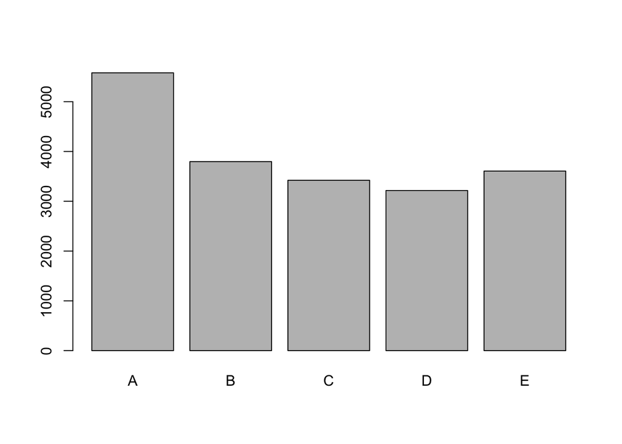

```r
barplot(table(pmltrain$classe))
```

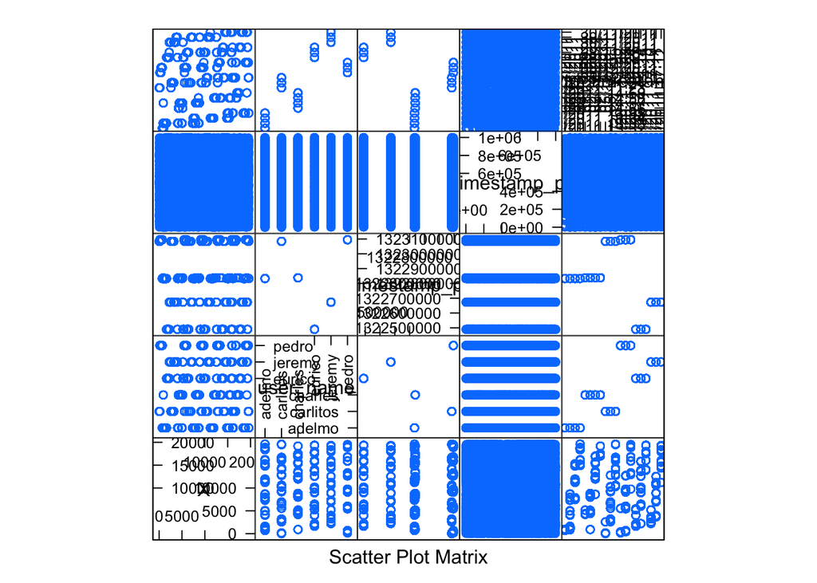

```r
splom(classe~pmltrain[1:5], data = pmltrain)
```

There are 159 common variables (classe is not one). I see if there are an null values that need to be accounted for. I then remove the nulls and make training and test sets from the pmltrain data with classe as the target variable. Next I control the classe balance and check if any nulls are generated due to the splitting. This is not a problem.

```r
test_na <-sapply(pmltest, FUN=function(x){
  length(which(is.na(x)))})
length(names(test_na[test_na==20]))
```

```
## [1] 100
```

```r
intrain <- createDataPartition(pmltrain$classe, p = 0.7, list=F)
training <- pmltrain[intrain,!names(pmltrain) %in% names(test_na[test_na>0])]
testing <- pmltrain[-intrain,!names(pmltrain) %in% names(test_na[test_na>0])]
prop.table(table(training$classe))
```

```
##
##         A         B         C         D         E
## 0.2843416 0.1934920 0.1744195 0.1639368 0.1838101
```

```r
prop.table(table(testing$classe))
```

```
##
##         A         B         C         D         E
## 0.2844520 0.1935429 0.1743415 0.1638063 0.1838573
```

```r
table(sapply(training, function(x){
  all(is.na(x))
}))
```

```
##
## FALSE
##    60
```

```r
table(sapply(testing, function(x){
  all(is.na(x))
}))
```

```
##
## FALSE
##    60
```

Next, I test the data and it fits very well!! I will double check this. Variable X predicts classe.

```r
fitlda <- train(classe~., method="lda", data = training)
confusionMatrix(fitlda)
```

```
## Bootstrapped (25 reps) Confusion Matrix
##
## (entries are percentual average cell counts across resamples)
##
##           Reference
## Prediction    A    B    C    D    E
##          A 28.5  0.0  0.0  0.0  0.0
##          B  0.0 19.4  0.0  0.0  0.0
##          C  0.0  0.0 17.4  0.0  0.0
##          D  0.0  0.0  0.0 16.3  0.0
##          E  0.0  0.0  0.0  0.0 18.4
##
##  Accuracy (average) : 0.9999
```

```r
lda_varimp <- varImp(fitlda)
head(lda_varimp$importance, 5)
```

```
##                                A          B          C          D
## X                    100.0000000 100.000000 100.000000 100.000000
## user_name              4.8927679   4.892768   4.892768   5.128175
## raw_timestamp_part_1  25.7032925  25.703293  25.703293  25.703293
## raw_timestamp_part_2   0.8218359   1.562432   2.216072   1.487203
## cvtd_timestamp        11.9371229  15.418413  11.017269  12.525417
##                               E
## X                    100.000000
## user_name              2.525818
## raw_timestamp_part_1  21.587376
## raw_timestamp_part_2   1.562432
## cvtd_timestamp        15.418413
```

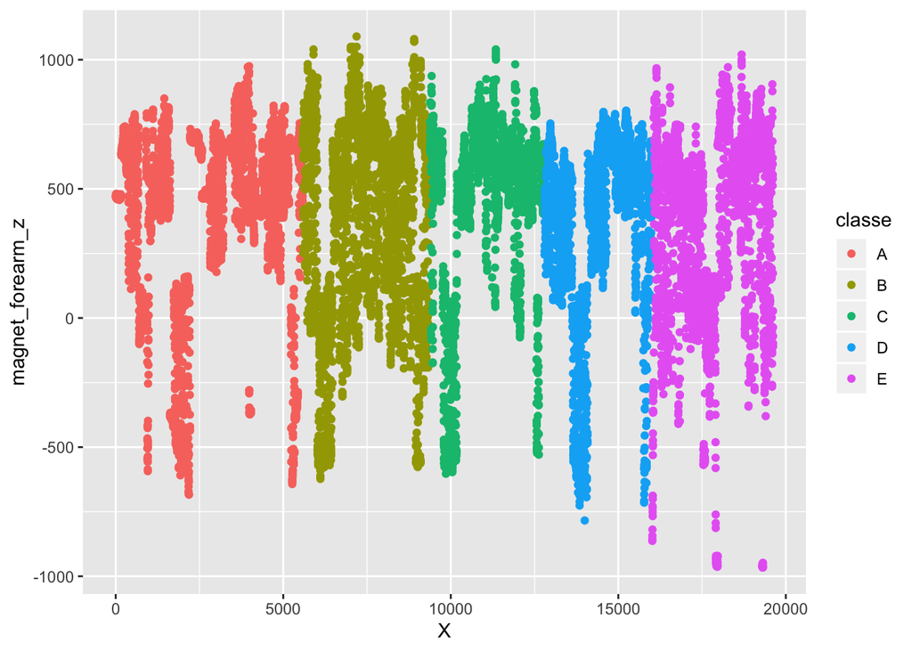

```r
qplot(X, magnet_forearm_z, colour=classe, data = training)
```

The plot confirms this, I then remove from test and train sets.

```r
cases <- pmltest$X
pmltrain$X <- NULL
pmltest$X <- NULL
training$X <- NULL
testing$X <- NULL
```

## Model Fit

I complete a 10 fold cross validation and evaluate for variablility and accuracy. Next I fit three models and compare. I use linear discim analysis, gradient boosting, and a decision tree. Once, these are modeled I see how they perform as far as cross validation accuracy and variability.

```r
fitcontrol <- trainControl(method="cv", number=10)

fitlda <- train(classe~., method="lda", data = training, trControl=fitcontrol)
fitgbm <- train(classe~., method="gbm", data = training, verbose=F, trControl=fitcontrol)
fittree <- train(classe~., method="rpart", data = training, trControl=fitcontrol)


print("LDA mean and sd")
```

```
## [1] "LDA mean and sd"
```

```r
mean(fitlda$resample$Accuracy)
```

```
## [1] 0.8537514
```

```r
sd(fitlda$resample$Accuracy)
```

```
## [1] 0.008313269
```

```r
print("GBM mean and sd")
```

```
## [1] "GBM mean and sd"
```

```r
mean(fitgbm$resample$Accuracy)
```

```
## [1] 0.9964331
```

```r
sd(fitgbm$resample$Accuracy)
```

```
## [1] 0.001054578
```

```r
print("decision tree mean and sd",mean(fittree$resample$Accuracy))
```

```
## [1] "decision tree mean and sd"
```

```r
mean(fittree$resample$Accuracy)
```

```
## [1] 0.5946067
```

```r
sd(fittree$resample$Accuracy)
```

```
## [1] 0.05237529
```

These models tell me that the decsion tree is the worst performing (has the highest standard deviation). The LDA model shows a pretty good model for the data, however after examining the GBM model I can see this is the best with the highest mean accuracy and a lower SD. Then I check out the sample errors for the models.

```r
1-mean(fittree$resample$Accuracy)
```

```
## [1] 0.4053933
```

```r
1-mean(fitlda$resample$Accuracy)
```

```
## [1] 0.1462486
```

```r
1-mean(fitgbm$resample$Accuracy)
```

```
## [1] 0.00356692
```

```r
predlda <- predict(fitlda, testing)
predgbm <- predict(fitgbm, testing)
predtree <- predict(fittree,testing)

confusionMatrix(predlda, testing$classe)$table
```

```
##           Reference
## Prediction    A    B    C    D    E
##          A 1521  136    3    0    0
##          B  130  835  112    2    0
##          C   23  157  885  116    3
##          D    0   11   23  793   97
##          E    0    0    3   53  982
```

```r
confusionMatrix(predlda, testing$classe)$overall[1]
```

```
##  Accuracy
## 0.8523364
```

```r
confusionMatrix(predgbm, testing$classe)$table
```

```
##           Reference
## Prediction    A    B    C    D    E
##          A 1673    0    0    0    0
##          B    1 1136    2    0    0
##          C    0    2 1018    4    0
##          D    0    1    6  958    4
##          E    0    0    0    2 1078
```

```r
confusionMatrix(predgbm, testing$classe)$overall[1]
```

```
##  Accuracy
## 0.9962617
```

```r
confusionMatrix(predtree, testing$classe)$table
```

```
##           Reference
## Prediction    A    B    C    D    E
##          A 1299  318   27   49   12
##          B    4  166    0    0    0
##          C  160  182  862  319  228
##          D  204  473  137  596  361
##          E    7    0    0    0  481
```

```r
confusionMatrix(predtree, testing$classe)$overall[1]
```

```
##  Accuracy
## 0.5784197
```

My deductions remain the same are previously. GBM is the best model. I will predict with gbm.

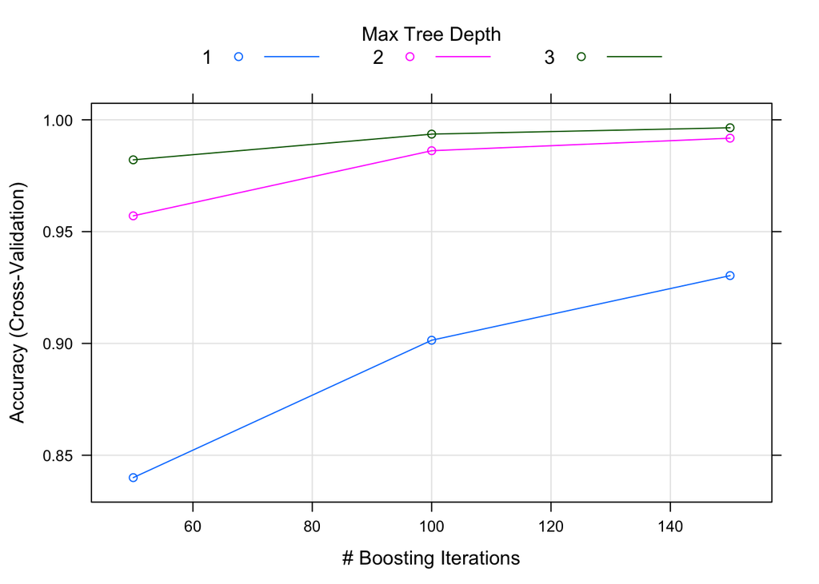

```r
plot(fitgbm)
```

```r
print(fitgbm$bestTune)
```

```
##   n.trees interaction.depth shrinkage n.minobsinnode
## 9     150                 3       0.1             10
```

```r
preds <- predict(fitgbm, pmltest)
data.frame(cases, preds)
```

```
##    cases preds
## 1      1     B
## 2      2     A
## 3      3     B
## 4      4     A
## 5      5     A
## 6      6     E
## 7      7     D
## 8      8     B
## 9      9     A
## 10    10     A
## 11    11     B
## 12    12     C
## 13    13     B
## 14    14     A
## 15    15     E
## 16    16     E
## 17    17     A
## 18    18     B
## 19    19     B
## 20    20     B
```

```r
cat("predict", paste(predict(fitgbm, pmltest)))
```

```
## predict B A B A A E D B A A B C B A E E A B B B
```